# Covid-19 Assignment

## Data Model

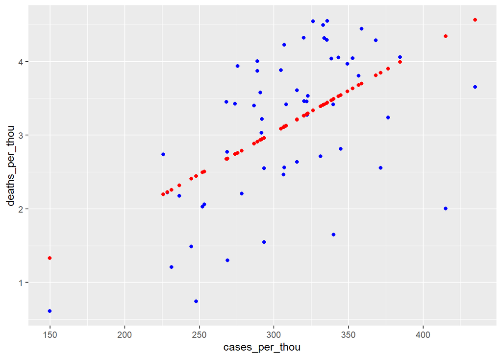

```r
# Deaths per thousand as represented by cases per thousand
mod <- lm(deaths_per_thou ~ cases_per_thou, data = US_state_totals)

# Predict on US state totals
US_tot_w_pred <- US_state_totals %>% mutate(pred = predict(mod))

# Plot predicted values compared to actual values
US_tot_w_pred %>% ggplot() + geom_point(aes(x = cases_per_thou, y = deaths_per_thou), color="blue") +
                  geom_point(aes(x = cases_per_thou, y = pred), color = "red")
```

# Personal Analysis

## Population Over Time

Above has been the lecture code, but I want to look more at population and it’s potential relationship with the number of cases and deaths.

I will first look at just one state and the population change over time. I will also refer back the the US_totals dataframe the compare the state to the whole of the US.

```r
# State population dataframe. I chose Colorado because that is where I am from.
state_pop <- US_by_state %>% select(Province_State, date, cases, Population, deaths) %>% filter(Province_State == "Colorado")

# Summary stats of populations
summary(state_pop$Population)
```

```
##    Min. 1st Qu.  Median    Mean 3rd Qu.    Max.
## 5758736 5758736 5758736 5758736 5758736 5758736
```

```r
summary(US_totals$Population)
```

```
##      Min.   1st Qu.    Median      Mean   3rd Qu.      Max.
## 332875137 332875137 332875137 332875137 332875137 332875137
```

Although I want to continue this analysis, the data appears to not be supported for this. The population data for Colorado and the whole of the US does not change over the course of the 3-4 years of the data. For this reason, I will need to shift my analysis.

Instead, I will look at US_state_totals dataframe in order to find some relationship between the states population and the deaths and cases.